# Practical Machine Learning Project

HD

December 24, 2015

# Executive Summary

## Background

Using devices such as *Jawbone Up*, *Nike FuelBand*, and *Fitbit* it is now possible to collect a large amount of data about personal activity relatively inexpensively. These type of devices are part of the quantified self movement – a group of enthusiasts who take measurements about themselves regularly to improve their health, to find patterns in their behavior, or because they are tech geeks.

Six participants performed barbell lifts in 5 different ways: *class A* corresponds to the correct execution of the exercise, while *classes B-E* correspond to the incorrect execution of the exercise.

## Data

The data for this project come from this source: http://groupware.les.inf.puc-rio.br/har.

The training data for this project are from here: https://d396qusza40orc.cloudfront.net/predmachlearn/pml-training.csv

The test data are from here: https://d396qusza40orc.cloudfront.net/predmachlearn/pml-testing.csv

# Pre-loading the R packages

```r
library(caret, quietly = TRUE)
```

```r
library(corrplot)
library(randomForest)
```

# A. Getting and Cleaning the Data

## A.1 Downloading and uploading the data

Download the data from the links to the current working directory:

```r
trainUrl <- "https://d396qusza40orc.cloudfront.net/predmachlearn/pml-training.csv"
testUrl <- "https://d396qusza40orc.cloudfront.net/predmachlearn/pml-testing.csv"
```

Upload the files to the memory, setting the missing data (i.e., NA, #DIV/0!, and “”) as NA:

```r
training<- read.csv("train.csv",
                    na.strings = c("NA", "#DIV/0!", ""))
testing<- read.csv("test.csv",
                    na.strings = c("NA", "#DIV/0!", ""))
```

## A.2 Cleaning near zero variables

```r
# returns the positions of the zero or near zero variables
NZV<- nearZeroVar(training)
# delete the near zero variables
training<- training[, -NZV]
testing<- testing[, -NZV]
```

## A.3 Deleting variables with more than *60%* *NAs*

```r
# calculate the percentage of NAs for each variable
mostNA<- sapply (training, function(x) mean(is.na(x))) > 0.6
# delete the based on the variable value
training<- training[, mostNA==FALSE]
testing<- testing[, mostNA==FALSE]
```

## A.4 Deleting the variables for information purpose

Take a quick look at the training data:

```r
str(training, list.len=10)
```

```
## 'data.frame':    19622 obs. of  59 variables:
##  $ X                   : int  1 2 3 4 5 6 7 8 9 10 ...
##  $ user_name           : Factor w/ 6 levels "adelmo","carlitos",..: 2 2 2 2 2 2 2 2 2 2 ...
##  $ raw_timestamp_part_1: int  1323084231 1323084231 1323084231 1323084232 1323084232 1323084232 1323084232 1323084232 1323084232 1323084232 ...
##  $ raw_timestamp_part_2: int  788290 808298 820366 120339 196328 304277 368296 440390 484323 484434 ...
##  $ cvtd_timestamp      : Factor w/ 20 levels "02/12/2011 13:32",..: 9 9 9 9 9 9 9 9 9 9 ...
##  $ num_window          : int  11 11 11 12 12 12 12 12 12 12 ...
##  $ roll_belt           : num  1.41 1.41 1.42 1.48 1.48 1.45 1.42 1.42 1.43 1.45 ...
##  $ pitch_belt          : num  8.07 8.07 8.07 8.05 8.07 8.06 8.09 8.13 8.16 8.17 ...
##  $ yaw_belt            : num  -94.4 -94.4 -94.4 -94.4 -94.4 -94.4 -94.4 -94.4 -94.4 -94.4 ...
##  $ total_accel_belt    : int  3 3 3 3 3 3 3 3 3 3 ...
##   [list output truncated]
```

The first 6 variables (*X*, *user_name*, *raw_timestamp_part_1*, *raw_timestamp_part_2*, *cvtd_timestamp*, and *num_window*) are for information purpose, therefore, delete them.

```r
training<- training[, -(1:6)]
testing<- testing[, -(1:6)]
```

# B. Slice the Data for Cross Validation

For the purpose of cross validation, split the cleaned training set into two groups: * training1 - 60% of the data for training the model * training2- 40% of the data for testing and accuracy measurement

```r
set.seed(12345)
inTrain <- createDataPartition(y=training$classe, p=0.60, list=FALSE)
training1  <- training[inTrain, ]
training2  <- training[-inTrain, ]
dim(training1)
```

```
## [1] 11776    53
```

```r
dim(training2)
```

```
## [1] 7846   53
```

# C. Developing the Model

## C.1 Selecting the most important variables for prediction

After cleaning the data, the total variables are reduced from 160 to 53 (52 of them as predictors, one of them as the outcome). This step is to select the most important variables for prediction.

An initial model was built based on Random Forest algorithm using all the 52 prediction variables in the *training1* data set:

```r
set.seed(678173)
initialModel <- randomForest(classe~., data = training1,
                 ntree = 100, importance = TRUE)
```

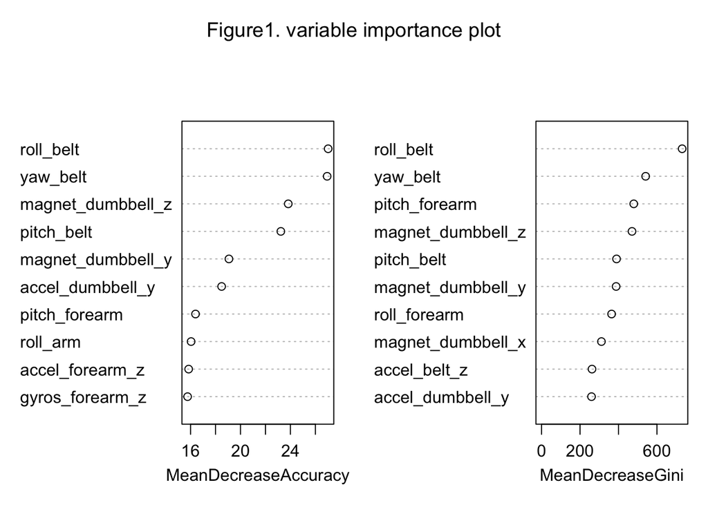

```r
varImpPlot (initialModel, n.var = 10,
            main = "Figure1. variable importance plot")
```

## C.2 Correlated predictors

```r
predictVar<- c("roll_belt", "yaw_belt", "pitch_belt", "magnet_dumbbell_z", "magnet_dumbbell_y", "accel_dumbbell_y", "gyros_arm_y", "gyros_forearm_y", "magnet_forearm_z", "pitch_forearm")
predictor_corr <- round(cor(training1[, predictVar]), 2)
```

The Figure 2 below visualized the correlation matrix using hierarchical cluster order as the ordering method:

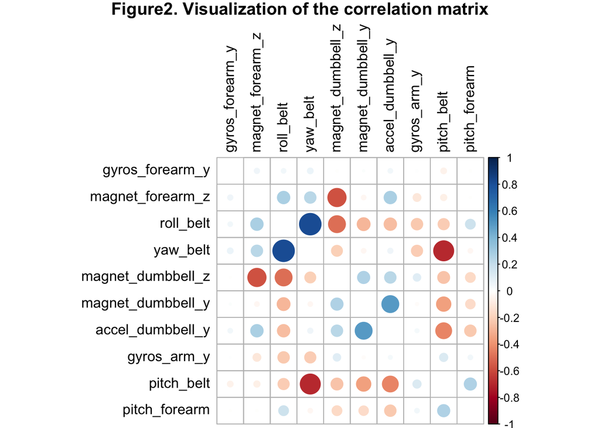

```r
corrplot(predictor_corr, order = "hclust", tl.col="black",
         diag = FALSE, tl.pos = "lt", mar=c(0,0,1,0),
         title = "Figure2. Visualization of the correlation matrix")
```

Figure 2 shows that *yaw_belt* and *roll_belt* have very high correlation, therefore, delete the *yaw_belt* variable.

## C.3 Fit the final model

```r
set.seed(76934)
finalModel <- train(classe~roll_belt+pitch_belt+
                      magnet_dumbbell_z+magnet_dumbbell_y+
                      accel_dumbbell_y+gyros_arm_y+
                      gyros_forearm_y+magnet_forearm_z+pitch_forearm,
                     data=training1, method="rf",
                     trControl=trainControl(method="cv",number=2),
                     prox=TRUE, verbose=TRUE, allowParallel=TRUE)
```

## C.4 Final model testing using *training2* and out of sample error estimation

Apply the *finalModel* on the *training2* data set to estimate the expected accuracy:

```r
predictions <- predict(finalModel, newdata=training2)
confusionMat <- confusionMatrix(predictions, training2$classe)
confusionMat
```

```
## Confusion Matrix and Statistics
##
##           Reference
## Prediction    A    B    C    D    E
##          A 2222   15    0    2    0
##          B    6 1475   10    0    6
##          C    1   21 1354   25    7
##          D    3    4    4 1256    5
##          E    0    3    0    3 1424
##
## Overall Statistics
##
##                Accuracy : 0.9853
##                  95% CI : (0.9824, 0.9879)
##     No Information Rate : 0.2845
##     P-Value [Acc > NIR] : < 2.2e-16
##
##                   Kappa : 0.9815
##  Mcnemar's Test P-Value : NA
##
## Statistics by Class:
##
##                      Class: A Class: B Class: C Class: D Class: E
## Sensitivity            0.9955   0.9717   0.9898   0.9767   0.9875
## Specificity            0.9970   0.9965   0.9917   0.9976   0.9991
## Pos Pred Value         0.9924   0.9853   0.9616   0.9874   0.9958
## Neg Pred Value         0.9982   0.9932   0.9978   0.9954   0.9972
## Prevalence             0.2845   0.1935   0.1744   0.1639   0.1838
## Detection Rate         0.2832   0.1880   0.1726   0.1601   0.1815
## Detection Prevalence   0.2854   0.1908   0.1795   0.1621   0.1823
## Balanced Accuracy      0.9962   0.9841   0.9907   0.9871   0.9933
```

**The accuracy for the final model on the testing dataset is *98.5%* which gives an estimated out of sample error of *1.5%*.**

# D. Course project submission

Apply the *finalModel* on the *testing* data set, and create 20 .TXT file for the submission:

```r
answers <- predict(finalModel, newdata=testing)
# function for creating a .txt file
pml_write_files = function(x)
  {
   n = length(x)
   for (i in 1:n)
     {
      filename = paste0("problem_id_", i, ".txt")
      write.table(x[i], file = filename, quote=FALSE, row.names=FALSE)
     }
  }
# run the pml_write_files
pml_write_files(answers)
```